Close search

# Data quality check Report - RMRP 2021

R4V Regional Platform

10 April 2021

## Introduction

The `RMRP 2021` is a database located on Activity Info server that contains the activities’information reported monthly by **12** countries in the Americas region for the *Response for Venezuelans* situation in 2021.

To the date of this report, **79** organisations reported a total of **6710** activities.

Despite that the Activity Info database contains validation rules and restrictions, some of the activities reported do have errors, that can then lead to misinterpretation of the results. For this reason, we developed a script to detect those errors and offer the concerned operations the possibility to modify their data or confirm that the value is correct. The following report is in mirror of the “Quality check report generator” developped by the regional platform, that can ben found and executed with the r4v_error_report() command in the 0_Run_analysis script.

For an easier lecture, the sections of the document will be divided in the same order they appear in Activity Info: Who / When / What / Where / To whom

we first display some general statistics to get an overview of the total numbers of activities, before entering into the details of the quality check

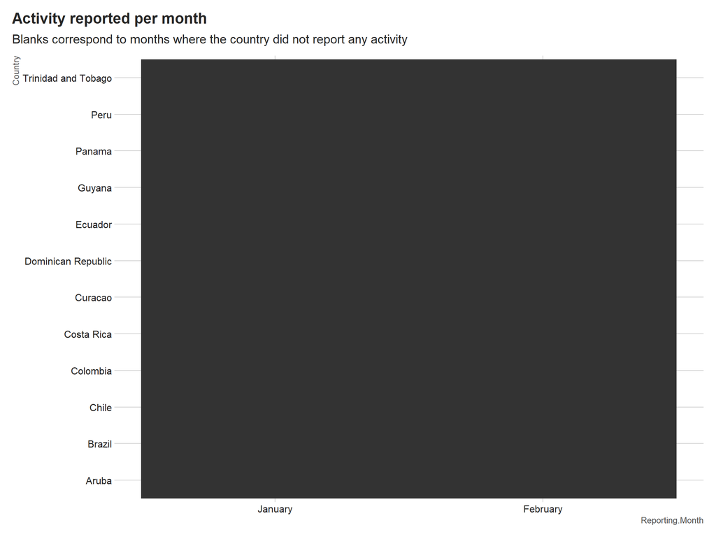

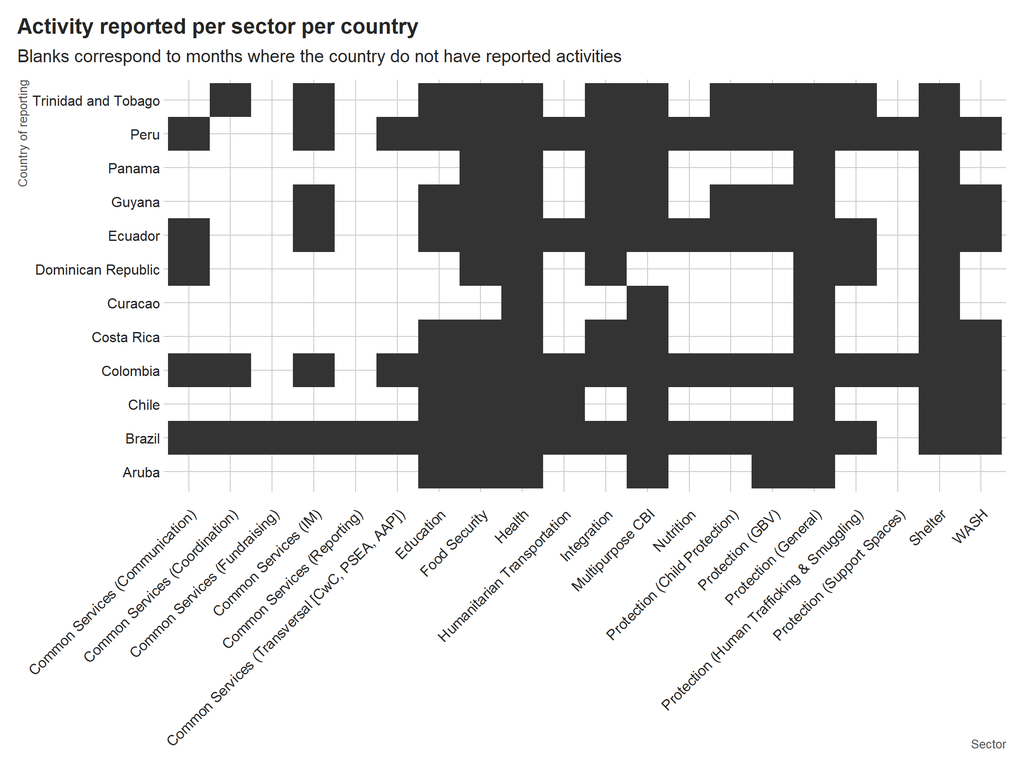

## Get the report of your errors

To get the complete error report, go to the R Script “2_quality_check_error_report_generator”. You will be able to have a complete report in an XLS format and be able to quickly identify the activities that contain errors and the type of errors for each activity.

### Checking empty mandatory text or selection values

One of the way to ensure the quality of data is to make the relevant fields mandatory. To initiate, we will check which one of the mandatory fields have missing values.

For the moment, and to avoid errors, we will only check the fields that are not depending of any skip logic or validation rules from a parent field as those will be checked later in each dedicated subsections. Those fields are: Appealing organisation Name, Implementation Set-up, Sector, Reporting month, Indicator, Activity name, COVID-19 Situation, RMRP Activity, CVA, Country, Admin1

```
#> [1] "None of the mandatory values are missing!"
```

## Who: Appealing organisation and Implementing partners

As mentioned in the introduction, **79** organisations have been reporting actvities so far. Out of the total of activities,**2975** are implemented through partners, representing a **44.3 %** of all the activities.

In those cases, it is important to highlight the work of those partners that are participating in the setup and don’t leave those information blank. The graph below represents the number of entries where the implementing partner is missing.

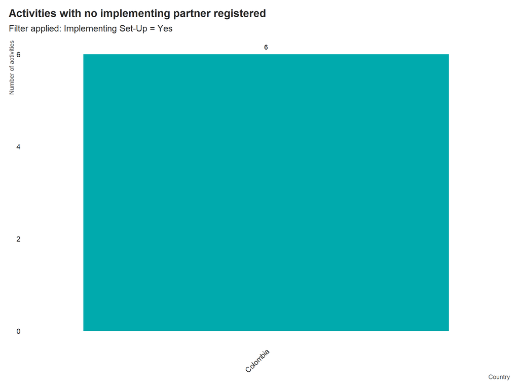

## What: Sectors, indicators and activity related information

Activities with no sector registered

```
#> [1] "None of the Sector values are missing!"
```

Activities with no indicator registered

```
#> [1] "None of the Indicator values are missing!"
```

Activities with no activity name registered

```
#> [1] "None of the Activity name values are missing!"
```

Sector and indicators are related and respect a validation process, to avoid having indicators related to the wrong sector. Below, a table exposes the number of rows where there is an error in the match between sector and indicator. If everything is correct, a text will inform you.

```
#> [1] "All the Sector and indicator values are correctly matched!"
```

## CVA related activities

CVA related activities contains both amount and delivery mechanism information. in this section, we’ll focus on 3 types of possible mistakes: missing values, outliers and erroneously filled values.

### Amounts and mechanisms assigned to non CVA activities

Assigning amounts and delivery mechanisms to non CVA activities can false the calculations made afterwards. We will identify rows of non CVA activity that actually contains data when it should be empty.

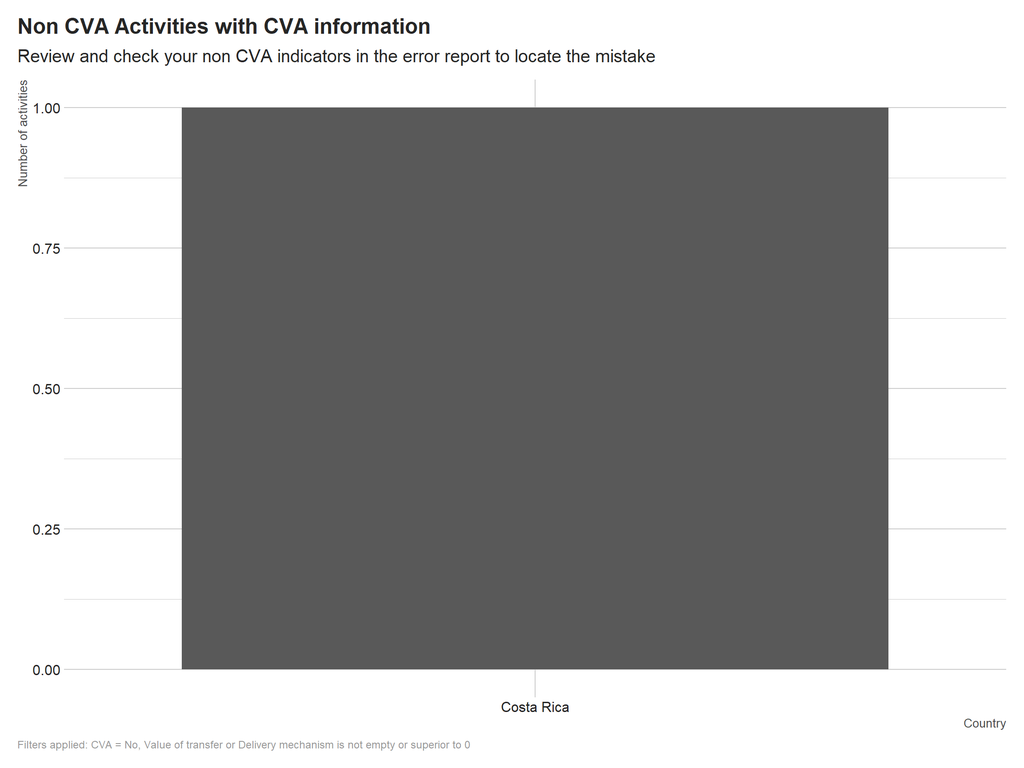

## Empty values in CVA activities

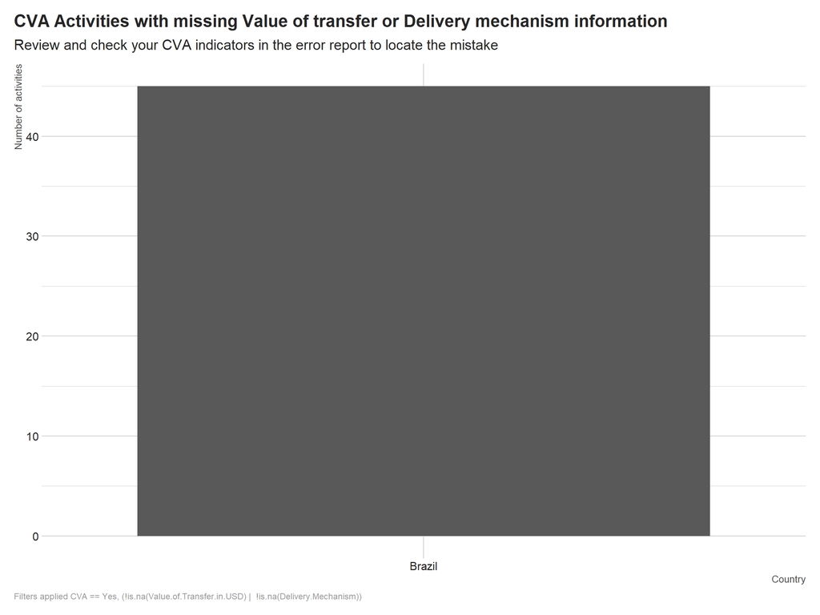

## Where: missing countries or Admin 1 values, incorrect matches between countries and Admin1

Empty geographical references country or Admin1

```
#> [1] "None of the Geographical values (Country or Admin1) are missing !"
```

Country and Admin1 geographical levels are related and respect a validation process, to avoid having Admin1 level areas related to the wrong country. Below, a table exposes the number of rows where there is an error in the match between sector and indicator. If everything is correct, a text will inform you.

```
#> [1] "All the Country and Admin1 values are correctly matched!"
```

## To whom: Incorrect assignments of values and beneficiaries breakdowns

One of the main inconsistencies identified in the previous reports is related to beneficiaries data, as Activity Info system does not detect the sums and mismatch between figures when loaded in bulk. Beneficiaries data is one of the most important and most asked information and thus it is important that this information is registered adequately and that the total values in each breakdown match.

In this section, we will run an analysis per type of indicator to separate beneficiaries related indicators and others. For this, we proceed to a table join between the activity table and the indicator table in order to later on be able to filter the data per *PIN/Target oriented* indicators and *People* indicators. We then only keep the columns that will be used in this section.

```r
dfindicator2 <- df2021%>%
  left_join(dfindicator, by = c("Sector...Subsector...WG", "Indicator"))%>%
  select(Appealing.Organization.Name, Reporting.Month,  Sector...Subsector...WG, Indicator, Country, Admin1, Quantity.of.unit.measured, Total.monthly.beneficiaries, New.beneficiaries.of.the.month, Refugees.and.Migrants.IN.DESTINATION, Refugees.and.Migrants.IN.TRANSIT, Host.Communities.Beneficiaries, Refugees.and.Migrants.PENDULARS,Colombian.Returnees, Women.under.18, Men.under.18, Women.above.18, Men.above.18, PiN.Target.Oriented, People)
```

We then calculate new columns to get the totals for both breakdowns and population type so we can do differences and identify the indicators where the totals are not corresponding. Once this calculations done, we compared the totals with the corresponding fields. In this process, we also replace **NA** values by **0**.

```r
dfindicatorclean <- dfindicator2%>%
  mutate_at(c('Refugees.and.Migrants.IN.DESTINATION', "Refugees.and.Migrants.IN.TRANSIT","Refugees.and.Migrants.PENDULARS", "Host.Communities.Beneficiaries", "Colombian.Returnees"), as.numeric)%>%
  mutate_if(is.numeric, ~replace(., is.na(.), 0))%>%
  mutate(total_pop_type = Refugees.and.Migrants.IN.DESTINATION+ Refugees.and.Migrants.IN.TRANSIT+ Host.Communities.Beneficiaries+ Colombian.Returnees ,total_breakdown = Women.under.18 + Men.under.18 + Women.above.18 + Men.above.18)
```

With those new columnns, we can identify the indicators with differences between the figures.

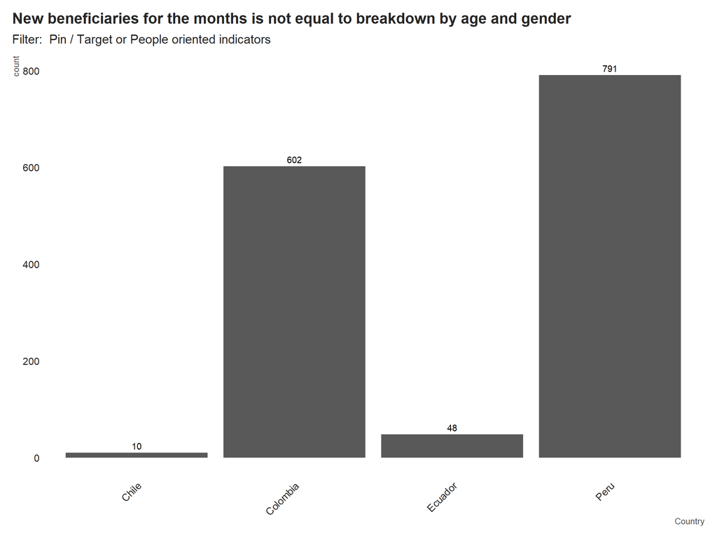

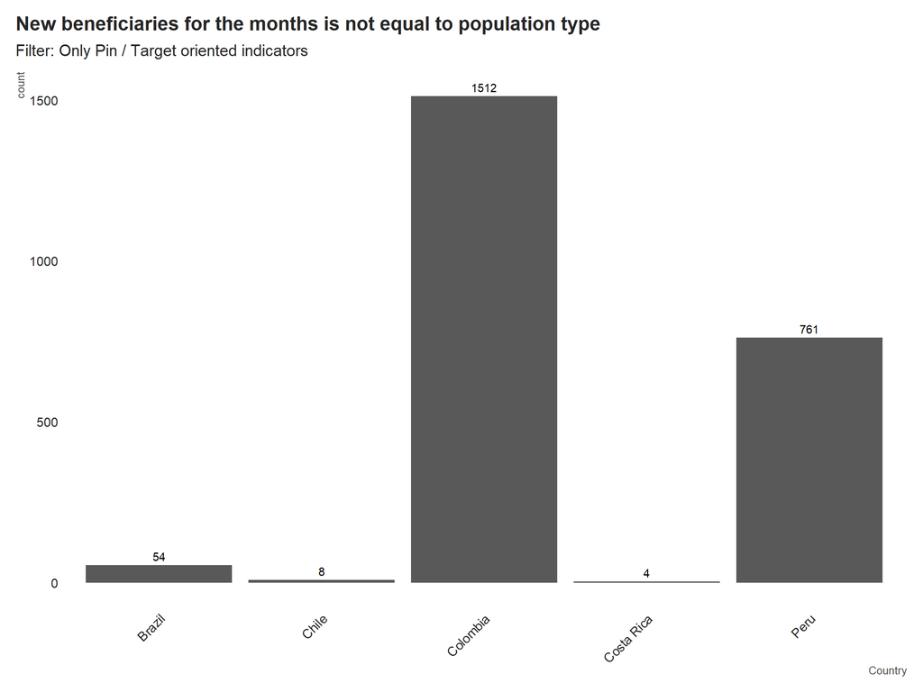

We do understand that breakdown information can be hard to obtain in certain contexts. For this reason, we propose to fill the empty breakdowns through national scripts with defined breakdown proportions.

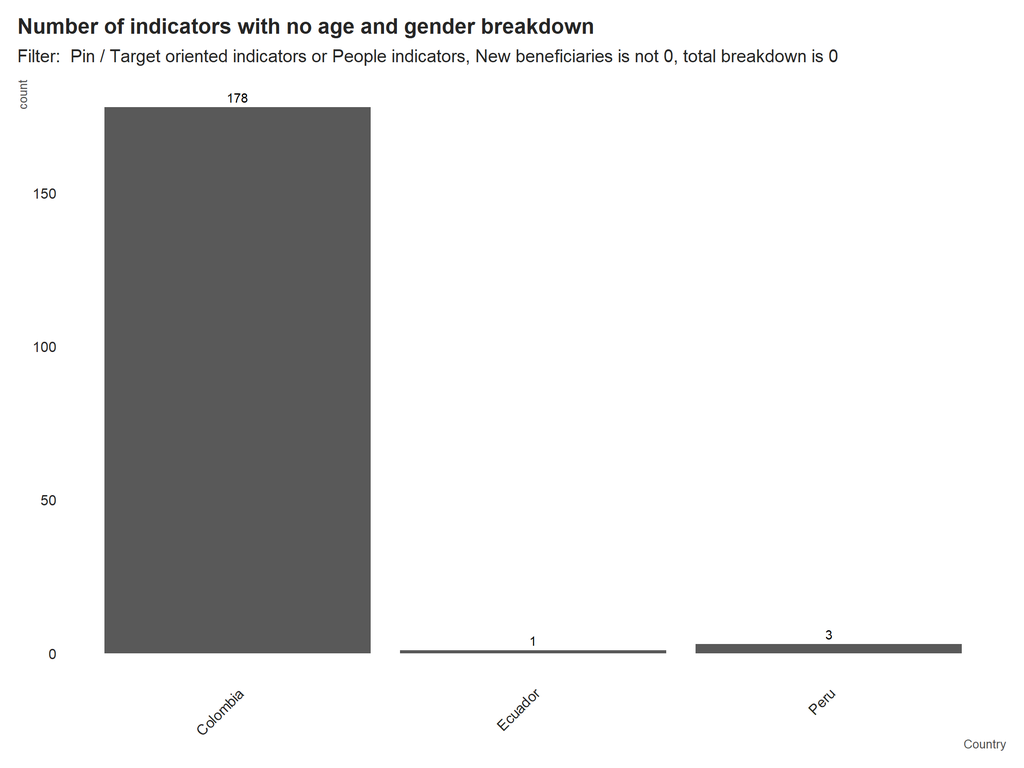

“People” indicators refer to indicators were the reported information refers to people that are not part of the Persons in Need (i.e.: # of teachers trained, # of healthcare workers trained,…). Those indicators have to be breakdowned by **age and gender only**. Thus, if those indicators contains a population type breakdown (Refugees and migrants in destination, host community,…), it should be removed.

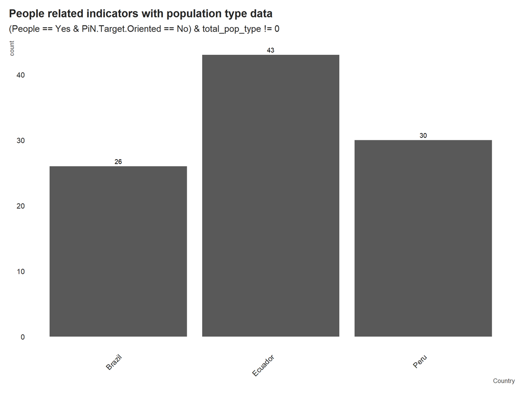

Indicators that are nor Pin/target oriented nor people oriented shouldn’t have data in the beneficiaries columns.

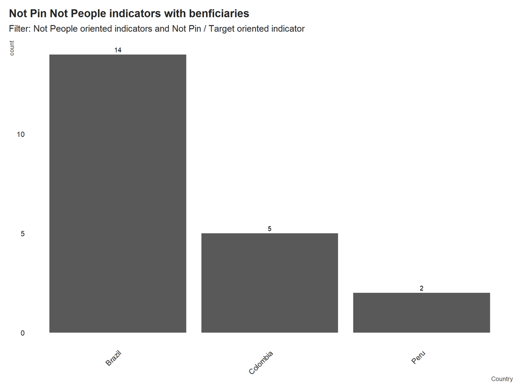

Pin and People oriented indicators should not have data in the “Quantity of unit measured” as their data should appear in Total and New beneficiaries columns.

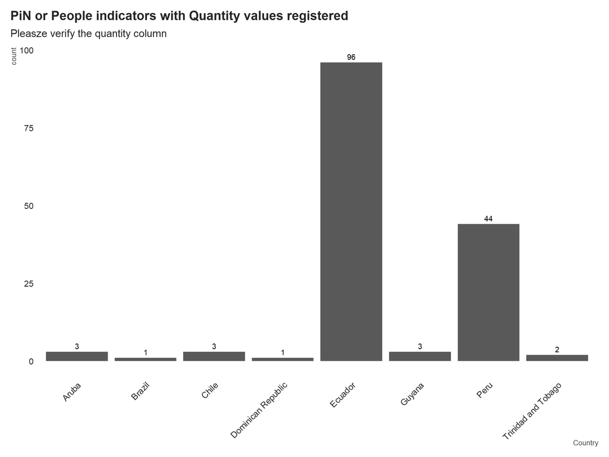